# QM 2022 Week 13: Wrap Up

### Step 1: Add (empty) `bib` file

*If you are already using any reference manager like Zotero or Mendeley, enter the texts you need into the manager as normal and export the `bib` (`Bibtex`) file into the project directory (where your `Rproj` file is located). Here is a way to do it in [Zotero](https://unimelb.libguides.com/latexbibtex/zotero) and in [Mendeley](https://www.imperial.ac.uk/media/imperial-college/administration-and-support-services/library/public/LaTeX-and-Mendeley-apr-2019.pdf).*

If your project does not yet have a file with `bib` extension in your project directory, you can either copy-paste a file like this from any of our lab projects or create a new file with this extension inside Rstudio: *File -> New File -> Text File -> Save as > “citations.bib” .*

### Step 2: Add Bibliography-related Parameters to YAML in `Rmd` file

Let’s say you now have the `citations.bib` file in the folder of the project folder and your `Rmd` file is located there as well. Visual Editor will add the correct file name into `bibliography:`, but you will still need to select the style. In the YAML header, you will need to add the following lines and I want Chicago-style in-text citations:

```markdown
bibliography: citations.bib
biblio-style: apsr
```

Style *apsr* is the style used in American Political Science Review, and this is the Chicago author-date style.

In case you need to use a very specific style that is not built-in, it will probably be available here: https://github.com/citation-style-language/styles. Styles are saved in `csl` files, so you will just need to download the file you need, put it in the project folder, and instead of `biblio-style` put `csl` parameter with the name of the respective file. For instance, if I wanted to use the style of *American Political Science Association*, I would write it like this if saved the `csl` file as `american-political-science-association.csl`:

```markdown
bibliography: citations.bib
csl: american-political-science-association.csl
```

### Step 3: Add *References* Section to the Document

The bibliography is typically placed at the end of the document, so your last heading should be something like `# References`.

### Step 4: Reference Items in the Text

Now open the Visual Editor mode, and then click on: *Insert -> Citation* (or just use a shortcut `Ctrl + Shift + F8`/`Cmd + Shift+F8`). There, you can use the Crossref database and search by title (make sure to select the correct version of the text!) or search by DOI.

Once you found the text, select if you’d like it in format *Author (2000)* or *(Author 2000)* with *Use in-text citation* option and *Insert* the citation. Your bib entrance will be added to your `bib` file.

Citations go inside square brackets and are separated by semicolons. Each citation must have a key, composed of ‘@’ + the citation identifier from the database, and may optionally have a prefix, a locator, and a suffix. Putting `[]` ensures that there are parenthesis around the citation.

```markdown
Blah blah [see @doe99, pp. 33-35; also @smith04, ch. 1].

Blah blah [@smith04; @doe99].
```

A minus sign `-` before the `@` will suppress mention of the author in the citation. This can be useful when the author is already mentioned in the text and you only need to include the year:

```markdown
Smith says blah [-@smith04].
```

This is how you get the in-text citations like *Smith (2004) says blah* and *Smith (2004, 33) says blah*.

```markdown
@smith04 says blah

@smith04 [p. 33] says blah
```

Rstudio now also have a nice illustrated guide on the topic: https://rstudio.github.io/visual-markdown-editing/citations.html

## Tables and Figures

Here is some general advice on how to make a good table and figures:

- Tables and figures should be clear, easily legible, and quickly understood by the reader
- Tables and figures should stand alone, and not require the reader to reference the text
- This requires a table/figure to minimally contain:
  - A title explaining the material concisely and clearly, with information about the outcome variable of other meaningful quantity of interest described
  - Information on the sample time period and number of observations included in the graphic
  - A note or notes that describe clearly what different cell entries or graphed material represents
  - Meaningful variable names or labels, which clearly indicate meaning
  - Clear and documented units of measurement
  - Legends and captions that provide additional information when necessary

Let’s look at an example:

**One-Sided Violence in Armed Conflict, 1989–2004**

|  | *Dependent variable:* |  |  |  |
| --- | --- | --- | --- | --- |
|  | Number killed in one-sided violence | os_best |  |  |
|  | *logistic* | *negative* |  |  |
|  |  | *binomial* |  |  |
|  | (1) | (2) | (3) | (4) |
| Civil War | 0.259*** |  |  |  |
|  | (0.030) |  |  |  |
| Autocracy | -0.241 |  |  |  |
|  | (0.442) |  |  |  |
| Democracy | -0.164*** |  |  |  |
|  | (0.025) |  |  |  |
| Polity Score |  | 1.015*** | 0.759** | 1.042*** |
|  |  | (0.347) | (0.344) | (0.363) |
| Polity Score<sup>2</sup> |  | 1.203*** | 0.780* |  |
|  |  | (0.437) | (0.415) |  |
| Government |  | 1.134** | 0.486 |  |
|  |  | (0.469) | (0.447) |  |
| One-sided Violence<sub>t-1</sub> |  |  |  | 0.002 |
|  |  |  |  | (0.027) |
| One-sided Violence<sub>t-1</sub>Autocracy |  |  |  | -0.002 |
|  |  |  |  | (0.006) |
| One-sided Violence<sub>t-1</sub>Democracy |  | 0.025 | -0.041 | -0.009 |
|  |  | (0.301) | (0.298) | (0.316) |
| Constant |  | 0.016*** | 0.011*** | 0.009*** |
|  |  | (0.004) | (0.001) | (0.001) |
| auto:prior_os |  | -0.007* |  |  |
|  |  | (0.004) |  |  |
| demo:prior_os |  | -0.011*** |  |  |
|  |  | (0.004) |  |  |
| Constant | -1.156** | 0.625 | 1.217** | 1.716*** |
|  | (0.484) | (0.574) | (0.559) | (0.525) |
| Observations | 1,000 | 1,159 | 1,157 | 1,102 |
| Log Likelihood | -468.672 | -2,336.735 | -2,309.927 | -2,172.654 |
| theta |  | 0.042*** (0.003) | 0.043*** (0.003) | 0.040*** (0.003) |
| Akaike Inf. Crit. | 945.344 | 4,689.470 | 4,631.853 | 4,357.308 |
| *Note:* | Standard errors in parenthesis. Excluding observation Rwanda 1994 |  |  |  |

> Is there anything missing in this table?

# 5 Throwback Wednesday/Thursday/Friday

Remember your first lab exercises?

## 5.1 Exercise I

*Create three objects:*

1. `my_lucky_number` it should contain your lucky number
2. `my_firstname` it should contain your first name
3. `my_lastname` it should contain your last name

*After you created the objects, call them separately. Don’t forget to add comments to your code.*

```r
# We first create the objects
my_lucky_number <-
  my_firstname <-
  my_lastname <-
  # Now we want to call the objects
  my_lucky_number
my_firstname
my_lastname
```

## 5.2 Exercise II

*Select and recode elements:*

1. Create two vectors: `vec1` and `vec2`.
   - `vec1` should contain 1, 56, 23, 89, -3 and 5 (in that order)
   - `vec2` contains 24, 78, 32, 27, 8 and 1
2. Now select elements of `vec1` that are greater than 5 or smaller than 0
3. Next set `vec1` to zero if `vec2` is greater than 30 and smaller or equal to 32

Remember your first homework?

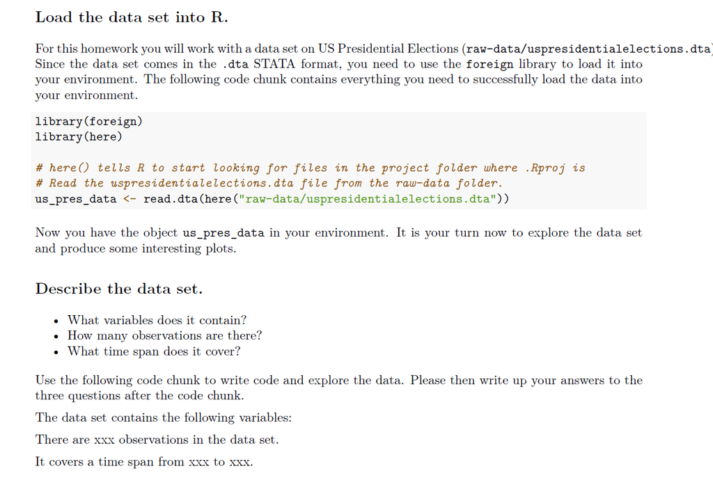

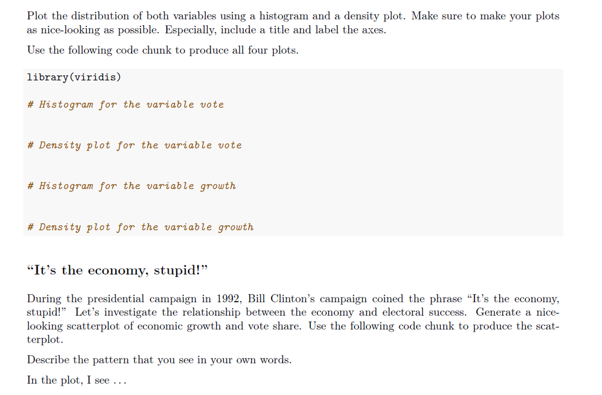

It took quite some time back then… How long do you think would it take you now?

It’s really amazing what you learnt this semester.

So we think you are well prepared to master the Data Essay!

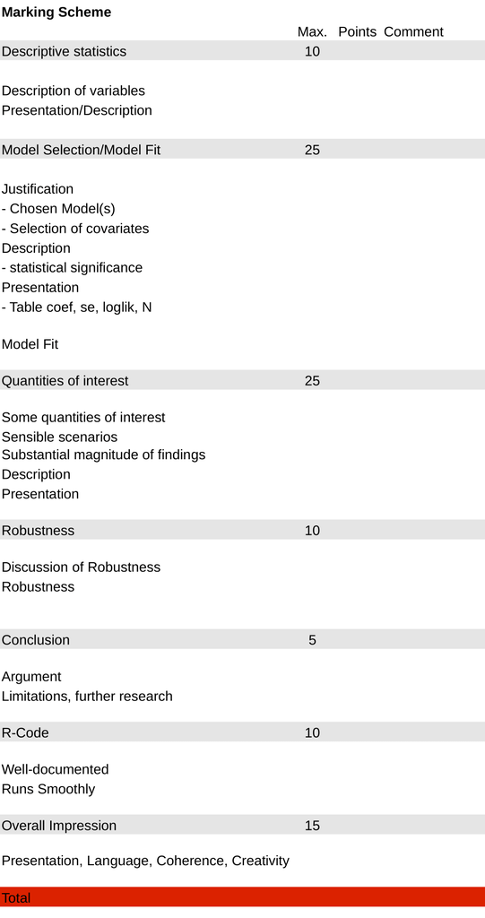

Data Essay Marking

# References

Cheibub, José Antonio, Jennifer Gandhi, and James Raymond Vreeland. 2009. “Democracy and Dictatorship Revisited.” *Public Choice* 143 (1-2): 67–101. https://doi.org/10.1007/s11127-009-9491-2.

Eck, Kristine, and Lisa Hultman. 2007. “One-Sided Violence Against Civilians in War: Insights from New Fatality Data.” *Journal of Peace Research* 44 (2): 233–46.

Hilbe, Joseph M. 2009. “Negative Binomial Regression.” https://doi.org/10.1017/cbo9780511973420.

Reuter, Ora John, and David Szakonyi. 2019. “Elite Defection Under Autocracy: Evidence from Russia.” *American Political Science Review* 113 (2): 552–68. https://doi.org/10.1017/s0003055419000030.

Scheve, Kenneth, and Matthew J. Slaughter. 2004. “Economic Insecurity and the Globalization of Production.” *American Journal of Political Science* 48 (4): 662–74. https://doi.org/10.1111/j.0092-5853.2004.00094.x.